# Noise Strike Lmer models

This notebook is the R-based version of model fitting. I will use the R interface for the following reasons:

1. support in my scientific community (incl. people in my lab) is better for statistical analysis in R than in pyhton.
2. the availability of statistical packages is better in R compared to python, and more of these packages are documented in scientific journal publications
3. comparing the outcome of the models fitted here to the models ultimately fitted in python is a sanity check for their robustness.

The specific aims of this notebook are:

1. load the datasets
2. standardize the independent variables, and compare the resulting distribution to the non-standardized form.
3. fit linear mixed effects models using the lme4 package
4. check the goodness of fit with rePCA
5. reduce the model till model assumptions are met

The above procedure is repeated for the model for reaction times and for the model for go/nogo responses.

The final model will then me re-executed in python, with pymer4 and statsmodels.

```r
# step 0: import all necessary libraries
library(ggplot2)
library(lme4)

# step 1: load the data
df <- read.csv('../2_cleaned/short_df_6.csv', header = TRUE)
df_norm <- df


# step 2: normalize independent variables
# df_norm$time_norm <- (df_norm$time-mean(df_norm$time))/sd(df_norm$time)
# normalize the positions
df_norm$posSet_1 <- (df_norm$posSet_1-mean(df_norm$posSet_1))/sd(df_norm$posSet_1)
df_norm$posSet_2 <- (df_norm$posSet_2-mean(df_norm$posSet_2))/sd(df_norm$posSet_2)
df_norm$posSet_3 <- (df_norm$posSet_3-mean(df_norm$posSet_3))/sd(df_norm$posSet_3)
df_norm$posSet_4 <- (df_norm$posSet_4-mean(df_norm$posSet_4))/sd(df_norm$posSet_4)
df_norm$posSet_5 <- (df_norm$posSet_5-mean(df_norm$posSet_5))/sd(df_norm$posSet_5)
df_norm$posSet_6 <- (df_norm$posSet_6-mean(df_norm$posSet_6))/sd(df_norm$posSet_6)

# normalize the probabilities
df_norm$pi_pos01 <- (df_norm$pi_pos01-mean(df_norm$pi_pos01))/sd(df_norm$pi_pos01)
df_norm$pi_pos02 <- (df_norm$pi_pos02-mean(df_norm$pi_pos02))/sd(df_norm$pi_pos01)
df_norm$pi_pos03 <- (df_norm$pi_pos03-mean(df_norm$pi_pos03))/sd(df_norm$pi_pos01)
df_norm$pi_pos04 <- (df_norm$pi_pos04-mean(df_norm$pi_pos04))/sd(df_norm$pi_pos01)
df_norm$pi_pos05 <- (df_norm$pi_pos05-mean(df_norm$pi_pos05))/sd(df_norm$pi_pos01)
df_norm$pi_pos06 <- (df_norm$pi_pos06-mean(df_norm$pi_pos06))/sd(df_norm$pi_pos01)


# step 3: compare the quantiles of normalized vs non-normalized ivs
par(mfrow=c(2,6))
qqplot(df_norm$posSet_1,df$posSet_1)
qqplot(df_norm$posSet_2,df$posSet_2)
```

```r
qqplot(df_norm$posSet_3,df$posSet_3)
qqplot(df_norm$posSet_4,df$posSet_4)
```

```r
qqplot(df_norm$posSet_5,df$posSet_5)
qqplot(df_norm$posSet_6,df$posSet_6)
```

```r
qqplot(df_norm$pi_pos01,df$pi_pos01)
qqplot(df_norm$pi_pos02,df$pi_pos02)
```

```r
qqplot(df_norm$pi_pos03,df$pi_pos03)
qqplot(df_norm$pi_pos04,df$pi_pos04)
```

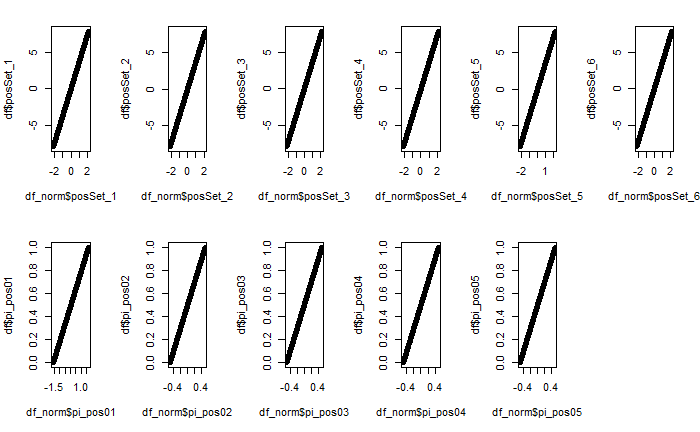

```r
qqplot(df_norm$pi_pos05,df$pi_pos05)
qqplot(df_norm$pi_pos06,df$pi_pos06)
```

```r
NA
NA
```

Conclusion: we can normalize both values here, the distribution won’t change.

## Part 1 Fitting REACTION TIMES

```r
# check if the model was already fitted
filename_maxrt <- '../2-3_Fitted/rt_max_lmer.R'

if (file.exists(filename_maxrt)){

  #rtm indicates a ReactionTime Model
  rtm0 <- readRDS(filename_maxrt)

}else {

  # First, we fit the maximum model for reaction time
rtm0 <- lmer('rea_time ~ 1 + pi_pos01 + pi_pos02 + pi_pos03 + pi_pos04 + pi_pos05 + pi_pos06 + posSet_1 + posSet_2 + posSet_3 + posSet_4 + posSet_5 + posSet_6 + pi_pos01:posSet_1 + pi_pos02:posSet_2 + pi_pos03:posSet_3 + pi_pos04:posSet_4 + pi_pos05:posSet_5 + pi_pos06:posSet_6 + (1 + pi_pos01 + pi_pos02 + pi_pos03 + pi_pos04 + pi_pos05 + pi_pos06 + posSet_1 + posSet_2 + posSet_3 + posSet_4 + posSet_5 + posSet_6|subject)', data = df_norm, REML = FALSE)

# and we save the model
saveRDS(rtm0 , file = filename_maxrt)

}
```

```
boundary (singular) fit: see ?isSingular
```

```r
summary(rtm0)
```

```
Linear mixed model fit by maximum likelihood  ['lmerMod']
Formula:
rea_time ~ 1 + pi_pos01 + pi_pos02 + pi_pos03 + pi_pos04 + pi_pos05 +
    pi_pos06 + posSet_1 + posSet_2 + posSet_3 + posSet_4 + posSet_5 +
    posSet_6 + pi_pos01:posSet_1 + pi_pos02:posSet_2 + pi_pos03:posSet_3 +
    pi_pos04:posSet_4 + pi_pos05:posSet_5 + pi_pos06:posSet_6 +
    (1 + pi_pos01 + pi_pos02 + pi_pos03 + pi_pos04 + pi_pos05 +
        pi_pos06 + posSet_1 + posSet_2 + posSet_3 + posSet_4 +
        posSet_5 + posSet_6 | subject)
   Data: df_norm

     AIC      BIC   logLik deviance df.resid
-10493.6  -9784.4   5357.8 -10715.6     4286

Scaled residuals:
    Min      1Q  Median      3Q     Max
-3.7542 -0.6738 -0.0688  0.6097  4.6822

Random effects:
 Groups   Name        Variance  Std.Dev.  Corr
 subject  (Intercept) 2.702e-03 0.0519800
          pi_pos01    4.164e-04 0.0204053  0.94
          pi_pos02    3.095e-04 0.0175926  0.74  0.68
          pi_pos03    7.728e-04 0.0277987 -0.52 -0.71 -0.74
          pi_pos04    2.320e-03 0.0481621 -0.87 -0.79 -0.31  0.13
          pi_pos05    8.486e-05 0.0092122  0.21 -0.11  0.41  0.29
          pi_pos06    1.131e-03 0.0336238  0.52  0.66 -0.09 -0.23
          posSet_1    2.043e-05 0.0045197  0.80  0.94  0.67 -0.88
          posSet_2    9.646e-07 0.0009822  0.98  0.96  0.82 -0.66
          posSet_3    6.674e-06 0.0025834 -0.90 -0.99 -0.72  0.80
          posSet_4    1.844e-06 0.0013580 -0.88 -0.97 -0.47  0.59
          posSet_5    3.602e-07 0.0006002  0.64  0.84  0.24 -0.62
          posSet_6    6.878e-06 0.0026226  0.57  0.52 -0.13  0.20
 Residual             5.073e-03 0.0712275






```

[output cut: 17 more lines]

```
pi_pos04           0.0281962  0.0280211   1.006
pi_pos05           0.0018721  0.0187697   0.100
pi_pos06          -0.0117693  0.0221589  -0.531
posSet_1          -0.0021381  0.0028373  -0.754
posSet_2          -0.0018438  0.0020216  -0.912
posSet_3           0.0018307  0.0024396   0.750
posSet_4           0.0003720  0.0021974   0.169
posSet_5           0.0010913  0.0021232   0.514
posSet_6           0.0001048  0.0024442   0.043
pi_pos01:posSet_1  0.0044311  0.0014417   3.073
pi_pos02:posSet_2  0.0008147  0.0045786   0.178
pi_pos03:posSet_3  0.0007957  0.0045373   0.175
pi_pos04:posSet_4 -0.0016022  0.0044257  -0.362
pi_pos05:posSet_5  0.0003061  0.0043745   0.070
pi_pos06:posSet_6 -0.0042486  0.0041230  -1.030
```

```
Correlation matrix not shown by default, as p = 19 > 12.
Use print(x, correlation=TRUE)  or
    vcov(x)        if you need it
```

```
optimizer (nloptwrap) convergence code: 0 (OK)
boundary (singular) fit: see ?isSingular
```

We already see that this model produces a Singularity warning. It also ran for a long time, which also indicates problem with the fitting. Let’s see if we can reduce the parameters in the random effects.

```r
# get the estimated parameters for the random effects

zapsmall(getME(rtm0,"theta"))
```

```
         subject.(Intercept) subject.pi_pos01.(Intercept)
                   0.7297747                    0.2703459
subject.pi_pos02.(Intercept) subject.pi_pos03.(Intercept)
                   0.1817390                   -0.2032366
subject.pi_pos04.(Intercept) subject.pi_pos05.(Intercept)
                  -0.5874729                    0.0268623
subject.pi_pos06.(Intercept) subject.posSet_1.(Intercept)
                   0.2462370                    0.0504820
subject.posSet_2.(Intercept) subject.posSet_3.(Intercept)
                   0.0135672                   -0.0328063
subject.posSet_4.(Intercept) subject.posSet_5.(Intercept)
                  -0.0168102                    0.0053780
subject.posSet_6.(Intercept)             subject.pi_pos01
                   0.0211107                    0.0947845
   subject.pi_pos02.pi_pos01    subject.pi_pos03.pi_pos01
                  -0.0072704                   -0.2527367
   subject.pi_pos04.pi_pos01    subject.pi_pos05.pi_pos01
                   0.0559483                   -0.1182521
   subject.pi_pos06.pi_pos01    subject.posSet_1.pi_pos01
                   0.2434072                    0.0371549
   subject.posSet_2.pi_pos01    subject.posSet_3.pi_pos01
                   0.0013921                   -0.0150345
   subject.posSet_4.pi_pos01    subject.posSet_5.pi_pos01
                  -0.0077178                    0.0059685
   subject.posSet_6.pi_pos01             subject.pi_pos02
                  -0.0026253                    0.1671013
   subject.pi_pos03.pi_pos02    subject.pi_pos04.pi_pos02
                  -0.2171120                    0.3300797
   subject.pi_pos05.pi_pos02    subject.pi_pos06.pi_pos02
                   0.0449157                   -0.3208602
   subject.posSet_1.pi_pos02    subject.posSet_2.pi_pos02
                   0.0098763                    0.0020319
   subject.posSet_3.pi_pos02    subject.posSet_4.pi_pos02
                  -0.0036354                    0.0046180
   subject.posSet_5.pi_pos02    subject.posSet_6.pi_pos02
                  -0.0025401                   -0.0300527
            subject.pi_pos03    subject.pi_pos04.pi_pos03
                   0.0007159                   -0.0005634
   subject.pi_pos05.pi_pos03    subject.pi_pos06.pi_pos03
                   0.0002641                   -0.0003013
```

[output cut: 37 more lines]

```
                   0.0000044                    0.0000249
   subject.posSet_4.posSet_2    subject.posSet_5.posSet_2
                  -0.0000194                   -0.0000135
   subject.posSet_6.posSet_2             subject.posSet_3
                  -0.0000046                    0.0000000
   subject.posSet_4.posSet_3    subject.posSet_5.posSet_3
                   0.0000245                   -0.0000289
   subject.posSet_6.posSet_3             subject.posSet_4
                   0.0000028                    0.0000046
   subject.posSet_5.posSet_4    subject.posSet_6.posSet_4
                   0.0000009                   -0.0000139
            subject.posSet_5    subject.posSet_6.posSet_5
                   0.0000175                   -0.0000076
            subject.posSet_6
                   0.0000224
```

Interpretation: the parmeter values here are effectively zero for most of the positions.

Next: with rePCA we can test specifically, how many of the random effect components we need to account for 100% of the variance

```r
# Probe the fitted model with rePCA


prc <- rePCA(rtm0)
class(prc)
```

```
[1] "prcomplist"
```

```r
length(prc)
```

```
[1] 1
```

```r
names(prc)
```

```
[1] "subject"
```

```r
class(prc$subject)
```

```
[1] "prcomp"
```

```r
prc$subject
```

```
Standard deviations (1, .., p=13):
 [1] 1.071174e+00 4.955469e-01 3.729395e-01 1.743753e-03
 [5] 3.154287e-04 2.114247e-04 6.496462e-05 5.032040e-05
 [9] 3.626901e-05 2.331070e-05 1.391779e-05 4.814552e-06
[13] 4.465518e-22

Rotation (n x k) = (13 x 13):
              [,1]          [,2]         [,3]         [,4]
 [1,] -0.660296898  3.124626e-01  0.244768347 -0.142646752
 [2,] -0.253607312  1.382792e-01 -0.160378238  0.308509392
 [3,] -0.128753230  4.032088e-01  0.121674767 -0.544438012
 [4,]  0.162418175 -5.721121e-01  0.547383219 -0.285292695
 [5,]  0.595355178  4.079476e-01 -0.263312088 -0.101683592
 [6,] -0.003668252  7.134365e-02  0.333408332  0.687869232
 [7,] -0.313101978 -4.648756e-01 -0.641795290 -0.094703490
```

[output cut: 48 more lines]

```r
summary(prc$subject)
```

```
Importance of components:
                         [,1]   [,2]    [,3]     [,4]      [,5]
Standard deviation     1.0712 0.4955 0.37294 0.001744 0.0003154
Proportion of Variance 0.7489 0.1603 0.09078 0.000000 0.0000000
Cumulative Proportion  0.7489 0.9092 1.00000 1.000000 1.0000000
                            [,6]      [,7]      [,8]      [,9]
Standard deviation     0.0002114 6.496e-05 5.032e-05 3.627e-05
Proportion of Variance 0.0000000 0.000e+00 0.000e+00 0.000e+00
Cumulative Proportion  1.0000000 1.000e+00 1.000e+00 1.000e+00
                           [,10]     [,11]     [,12]     [,13]
Standard deviation     2.331e-05 1.392e-05 4.815e-06 4.466e-22
Proportion of Variance 0.000e+00 0.000e+00 0.000e+00 0.000e+00
Cumulative Proportion  1.000e+00 1.000e+00 1.000e+00 1.000e+00
```

Important for the interpretation it the cumulative proportion 3 components are enough to account for 100% of the variance. But which components shall we use?

The components above refer to PCA components. They are not 1:1 translatable to random effect components.

But we can check the random effect components from the model itself: the position terms account for less variance than the probability and the intercept. So we’ll remove all position terms from the random effects.

```r
rtm1 <- lmer('rea_time ~ 1 + pi_pos01 + pi_pos02 + pi_pos03 + pi_pos04 + pi_pos05 + pi_pos06 + posSet_1 + posSet_2 + posSet_3 + posSet_4 + posSet_5 + posSet_6 + pi_pos01:posSet_1 + pi_pos02:posSet_2 + pi_pos03:posSet_3 + pi_pos04:posSet_4 + pi_pos05:posSet_5 + pi_pos06:posSet_6 + (1 + pi_pos01 + pi_pos02 + pi_pos03 + pi_pos04 + pi_pos05 + pi_pos06|subject)', data = df_norm, REML = FALSE)
```

```
boundary (singular) fit: see ?isSingular
```

```r
summary(rtm1)
```

```
Linear mixed model fit by maximum likelihood  ['lmerMod']
Formula:
rea_time ~ 1 + pi_pos01 + pi_pos02 + pi_pos03 + pi_pos04 + pi_pos05 +
    pi_pos06 + posSet_1 + posSet_2 + posSet_3 + posSet_4 + posSet_5 +
    posSet_6 + pi_pos01:posSet_1 + pi_pos02:posSet_2 + pi_pos03:posSet_3 +
    pi_pos04:posSet_4 + pi_pos05:posSet_5 + pi_pos06:posSet_6 +
    (1 + pi_pos01 + pi_pos02 + pi_pos03 + pi_pos04 + pi_pos05 +
        pi_pos06 | subject)
   Data: df_norm

     AIC      BIC   logLik deviance df.resid
-10599.7 -10293.1   5347.9 -10695.7     4349

Scaled residuals:
    Min      1Q  Median      3Q     Max
-3.7249 -0.6804 -0.0673  0.6087  4.6860

Random effects:
 Groups   Name        Variance  Std.Dev. Corr
 subject  (Intercept) 2.690e-03 0.05187
          pi_pos01    4.259e-04 0.02064   0.95
          pi_pos02    2.327e-04 0.01525   0.99  0.89
          pi_pos03    5.683e-04 0.02384  -0.73 -0.90 -0.63
          pi_pos04    1.865e-03 0.04319  -0.90 -0.84 -0.90  0.53
          pi_pos05    8.873e-05 0.00942   0.22 -0.09  0.35  0.38
          pi_pos06    9.660e-04 0.03108   0.50  0.68  0.41 -0.64
 Residual             5.100e-03 0.07142






 -0.11
 -0.69 -0.64

Number of obs: 4397, groups:  subject, 4

Fixed effects:
                    Estimate Std. Error t value
(Intercept)        5.570e-01  2.599e-02  21.432
pi_pos01          -3.348e-02  1.047e-02  -3.198
pi_pos02          -5.582e-02  1.073e-02  -5.200
pi_pos03           4.303e-02  1.606e-02   2.680
pi_pos04           2.705e-02  2.595e-02   1.043
pi_pos05           3.344e-03  1.885e-02   0.177
pi_pos06          -1.215e-02  2.127e-02  -0.571
posSet_1          -1.105e-03  1.707e-03  -0.647
posSet_2          -1.571e-03  1.966e-03  -0.799
posSet_3           1.224e-03  2.071e-03   0.591
posSet_4           7.537e-05  2.095e-03   0.036
posSet_5           1.291e-03  2.108e-03   0.612
posSet_6           6.609e-04  2.054e-03   0.322
pi_pos01:posSet_1  4.059e-03  1.444e-03   2.810
pi_pos02:posSet_2  7.170e-04  4.591e-03   0.156
pi_pos03:posSet_3  1.204e-03  4.546e-03   0.265
pi_pos04:posSet_4 -1.515e-03  4.433e-03  -0.342
pi_pos05:posSet_5 -8.011e-05  4.387e-03  -0.018
pi_pos06:posSet_6 -4.650e-03  4.124e-03  -1.127
```

```
Correlation matrix not shown by default, as p = 19 > 12.
Use print(x, correlation=TRUE)  or
    vcov(x)        if you need it
```

```
optimizer (nloptwrap) convergence code: 0 (OK)
boundary (singular) fit: see ?isSingular
```

The model is still singular and did not converge. Is the covariance structure still degenerated?

```r
# print only the summary of the reaction time covariance matrix
summary(rePCA(rtm1))
```

```
$subject
Importance of components:
                         [,1]   [,2]    [,3]     [,4]      [,5]
Standard deviation     1.0500 0.3889 0.29465 0.001034 0.0002515
Proportion of Variance 0.8224 0.1128 0.06476 0.000000 0.0000000
Cumulative Proportion  0.8224 0.9352 1.00000 1.000000 1.0000000
                            [,6] [,7]
Standard deviation     3.945e-05    0
Proportion of Variance 0.000e+00    0
Cumulative Proportion  1.000e+00    1
```

Yes, it seems like we can reduce the model even further and keep only random effects for the intercept and the probability of time point 4.

```r
rtm2 <- lmer('rea_time ~ 1 + pi_pos01 + pi_pos02 + pi_pos03 + pi_pos04 + pi_pos05 + pi_pos06 + posSet_1 + posSet_2 + posSet_3 + posSet_4 + posSet_5 + posSet_6 + pi_pos01:posSet_1 + pi_pos02:posSet_2 + pi_pos03:posSet_3 + pi_pos04:posSet_4 + pi_pos05:posSet_5 + pi_pos06:posSet_6 + (1 + pi_pos04|subject)', data = df_norm, REML = FALSE)
```

```
boundary (singular) fit: see ?isSingular
```

```r
summary(rtm2)
```

```
Linear mixed model fit by maximum likelihood  ['lmerMod']
Formula:
rea_time ~ 1 + pi_pos01 + pi_pos02 + pi_pos03 + pi_pos04 + pi_pos05 +
    pi_pos06 + posSet_1 + posSet_2 + posSet_3 + posSet_4 + posSet_5 +
    posSet_6 + pi_pos01:posSet_1 + pi_pos02:posSet_2 + pi_pos03:posSet_3 +
    pi_pos04:posSet_4 + pi_pos05:posSet_5 + pi_pos06:posSet_6 +
    (1 + pi_pos04 | subject)
   Data: df_norm

     AIC      BIC   logLik deviance df.resid
-10461.9 -10315.0   5254.0 -10507.9     4374

Scaled residuals:
    Min      1Q  Median      3Q     Max
-3.4901 -0.6893 -0.0814  0.6325  4.3067

Random effects:
 Groups   Name        Variance  Std.Dev. Corr
 subject  (Intercept) 3.503e-03 0.059185
          pi_pos04    6.585e-05 0.008115 -1.00
 Residual             5.335e-03 0.073038
Number of obs: 4397, groups:  subject, 4

Fixed effects:
                    Estimate Std. Error t value
(Intercept)        0.5533367  0.0296411  18.668
pi_pos01          -0.0287785  0.0017666 -16.290
pi_pos02          -0.0484554  0.0077333  -6.266
pi_pos03           0.0368874  0.0109008   3.384
pi_pos04           0.0165450  0.0150248   1.101
pi_pos05           0.0006267  0.0186424   0.034
pi_pos06          -0.0010241  0.0145935  -0.070
posSet_1          -0.0008578  0.0017448  -0.492
posSet_2          -0.0016307  0.0020103  -0.811
posSet_3           0.0005875  0.0021170   0.278
posSet_4           0.0007944  0.0021384   0.371
posSet_5           0.0011969  0.0021547   0.555
posSet_6           0.0007724  0.0020984   0.368
pi_pos01:posSet_1  0.0037209  0.0014765   2.520
pi_pos02:posSet_2  0.0007894  0.0046945   0.168
pi_pos03:posSet_3  0.0028982  0.0046452   0.624
pi_pos04:posSet_4 -0.0020537  0.0045276  -0.454
pi_pos05:posSet_5  0.0003715  0.0044827   0.083
pi_pos06:posSet_6 -0.0061228  0.0042156  -1.452
```

```
Correlation matrix not shown by default, as p = 19 > 12.
Use print(x, correlation=TRUE)  or
    vcov(x)        if you need it
```

```
optimizer (nloptwrap) convergence code: 0 (OK)
boundary (singular) fit: see ?isSingular
```

```r
# print only the summary of the reaction time covariance matrix
summary(rePCA(rtm2))
```

```
$subject
Importance of components:
                         [,1] [,2]
Standard deviation     0.8179    0
Proportion of Variance 1.0000    0
Cumulative Proportion  1.0000    1
```

The intercept explain enough variance so that we can get rid of the last term, too.

```r
rtm3 <- lmer('rea_time ~ 1 + pi_pos01 + pi_pos02 + pi_pos03 + pi_pos04 + pi_pos05 + pi_pos06 + posSet_1 + posSet_2 + posSet_3 + posSet_4 + posSet_5 + posSet_6 + + pi_pos01:posSet_1 + pi_pos02:posSet_2 + pi_pos03:posSet_3 + pi_pos04:posSet_4 + pi_pos05:posSet_5 + pi_pos06:posSet_6 +(1|subject)', data = df_norm, REML = FALSE)

summary(rtm3)
```

```
Linear mixed model fit by maximum likelihood  ['lmerMod']
Formula:
rea_time ~ 1 + pi_pos01 + pi_pos02 + pi_pos03 + pi_pos04 + pi_pos05 +
    pi_pos06 + posSet_1 + posSet_2 + posSet_3 + posSet_4 + posSet_5 +
    posSet_6 + +pi_pos01:posSet_1 + pi_pos02:posSet_2 + pi_pos03:posSet_3 +
    pi_pos04:posSet_4 + pi_pos05:posSet_5 + pi_pos06:posSet_6 +
    (1 | subject)
   Data: df_norm

     AIC      BIC   logLik deviance df.resid
-10459.9 -10325.8   5251.0 -10501.9     4376

Scaled residuals:
    Min      1Q  Median      3Q     Max
-3.5329 -0.6888 -0.0797  0.6399  4.3301

Random effects:
 Groups   Name        Variance Std.Dev.
 subject  (Intercept) 0.003227 0.05681
 Residual             0.005342 0.07309
Number of obs: 4397, groups:  subject, 4

Fixed effects:
                    Estimate Std. Error t value
(Intercept)        0.5541668  0.0284549  19.475
pi_pos01          -0.0287123  0.0017677 -16.242
pi_pos02          -0.0486108  0.0077379  -6.282
pi_pos03           0.0368929  0.0109078   3.382
pi_pos04           0.0149526  0.0144774   1.033
pi_pos05           0.0002944  0.0186551   0.016
pi_pos06          -0.0012905  0.0146031  -0.088
posSet_1          -0.0006704  0.0017460  -0.384
posSet_2          -0.0017895  0.0020116  -0.890
posSet_3           0.0004413  0.0021182   0.208
posSet_4           0.0006210  0.0021397   0.290
posSet_5           0.0011541  0.0021561   0.535
posSet_6           0.0008621  0.0020998   0.411
pi_pos01:posSet_1  0.0036656  0.0014776   2.481
pi_pos02:posSet_2  0.0012098  0.0046973   0.258
pi_pos03:posSet_3  0.0032917  0.0046480   0.708
pi_pos04:posSet_4 -0.0016348  0.0045304  -0.361
pi_pos05:posSet_5  0.0003065  0.0044856   0.068
pi_pos06:posSet_6 -0.0064356  0.0042184  -1.526
```

```
Correlation matrix not shown by default, as p = 19 > 12.
Use print(x, correlation=TRUE)  or
    vcov(x)        if you need it
```

This model does not throw a singularity warning. Next, we will reduce the parameters in the fixed effects structure.

We can see in the model summary above, that the interaction terms account for very little variance. They are also the most complex fixed effect - therefore, we will remove them.

```r
rtm4 <- lmer('rea_time ~ 1 + pi_pos01 + pi_pos02 + pi_pos03 + pi_pos04 + pi_pos05 + pi_pos06 + posSet_1 + posSet_2 + posSet_3 + posSet_4 + posSet_5 + posSet_6 + (1|subject)', data = df_norm, REML = FALSE)

summary(rtm4)
```

```
Linear mixed model fit by maximum likelihood  ['lmerMod']
Formula:
rea_time ~ 1 + pi_pos01 + pi_pos02 + pi_pos03 + pi_pos04 + pi_pos05 +
    pi_pos06 + posSet_1 + posSet_2 + posSet_3 + posSet_4 + posSet_5 +
    posSet_6 + (1 | subject)
   Data: df_norm

     AIC      BIC   logLik deviance df.resid
-10462.0 -10366.1   5246.0 -10492.0     4382

Scaled residuals:
    Min      1Q  Median      3Q     Max
-3.4943 -0.6736 -0.0815  0.6330  4.4039

Random effects:
 Groups   Name        Variance Std.Dev.
 subject  (Intercept) 0.003229 0.05683
 Residual             0.005354 0.07317
Number of obs: 4397, groups:  subject, 4

Fixed effects:
              Estimate Std. Error t value
(Intercept)  0.5540520  0.0284627  19.466
pi_pos01    -0.0286870  0.0017685 -16.221
pi_pos02    -0.0489175  0.0077416  -6.319
pi_pos03     0.0388240  0.0108755   3.570
pi_pos04     0.0136751  0.0144669   0.945
pi_pos05     0.0011561  0.0186661   0.062
pi_pos06    -0.0022978  0.0146093  -0.157
posSet_1     0.0007112  0.0015885   0.448
posSet_2    -0.0012310  0.0015928  -0.773
posSet_3     0.0018732  0.0016067   1.166
posSet_4     0.0001759  0.0016175   0.109
posSet_5     0.0012805  0.0016131   0.794
posSet_6    -0.0012707  0.0016010  -0.794
```

```
Correlation matrix not shown by default, as p = 13 > 12.
Use print(x, correlation=TRUE)  or
    vcov(x)        if you need it
```

The position also accounts for only a small proportion of the variance, so we will get rid of the position, too.

```r
rtm5 <- lmer('rea_time ~ 1 + pi_pos01 + pi_pos02 + pi_pos03 + pi_pos04 + pi_pos05 + pi_pos06 + (1|subject)', data = df_norm, REML = FALSE)

summary(rtm5)
```

```
Linear mixed model fit by maximum likelihood  ['lmerMod']
Formula:
rea_time ~ 1 + pi_pos01 + pi_pos02 + pi_pos03 + pi_pos04 + pi_pos05 +
    pi_pos06 + (1 | subject)
   Data: df_norm

     AIC      BIC   logLik deviance df.resid
-10469.9 -10412.4   5244.0 -10487.9     4388

Scaled residuals:
    Min      1Q  Median      3Q     Max
-3.4845 -0.6829 -0.0874  0.6338  4.4411

Random effects:
 Groups   Name        Variance Std.Dev.
 subject  (Intercept) 0.003224 0.05678
 Residual             0.005359 0.07320
Number of obs: 4397, groups:  subject, 4

Fixed effects:
              Estimate Std. Error t value
(Intercept)  0.5541874  0.0284379  19.488
pi_pos01    -0.0287566  0.0017662 -16.282
pi_pos02    -0.0487550  0.0077339  -6.304
pi_pos03     0.0386293  0.0108694   3.554
pi_pos04     0.0136912  0.0144667   0.946
pi_pos05     0.0002751  0.0186651   0.015
pi_pos06    -0.0014719  0.0146046  -0.101

Correlation of Fixed Effects:
         (Intr) p_ps01 p_ps02 p_ps03 p_ps04 p_ps05
pi_pos01 -0.008
pi_pos02 -0.009 -0.412
pi_pos03 -0.005  0.023 -0.457
pi_pos04  0.001 -0.004 -0.004 -0.494
pi_pos05  0.001 -0.003  0.012  0.001 -0.494
pi_pos06 -0.004  0.005  0.000  0.004  0.012 -0.793
```

Finally, we remove the probability effects where the Standard Error is larger than the estimate (pi04, pi05, pi06)

```r
rtm6 <- lmer('rea_time ~ 1 + pi_pos01 + pi_pos02 + pi_pos03 + (1|subject)', data = df_norm, REML = FALSE)

summary(rtm6)
```

```
Linear mixed model fit by maximum likelihood  ['lmerMod']
Formula:
rea_time ~ 1 + pi_pos01 + pi_pos02 + pi_pos03 + (1 | subject)
   Data: df_norm

     AIC      BIC   logLik deviance df.resid
-10473.9 -10435.5   5242.9 -10485.9     4391

Scaled residuals:
    Min      1Q  Median      3Q     Max
-3.4867 -0.6857 -0.0876  0.6304  4.4396

Random effects:
 Groups   Name        Variance Std.Dev.
 subject  (Intercept) 0.003225 0.05679
 Residual             0.005361 0.07322
Number of obs: 4397, groups:  subject, 4

Fixed effects:
             Estimate Std. Error t value
(Intercept)  0.554313   0.028443  19.489
pi_pos01    -0.028741   0.001767 -16.269
pi_pos02    -0.048941   0.007733  -6.329
pi_pos03     0.051166   0.006391   8.006

Correlation of Fixed Effects:
         (Intr) p_ps01 p_ps02
pi_pos01 -0.008
pi_pos02 -0.009 -0.412
pi_pos03 -0.013  0.031 -0.752
```

Next, we want to compare all models by their AIC

```r
list(summary(rtm0)$AIC[1], summary(rtm1)$AIC[1], summary(rtm2)$AIC[1], summary(rtm3)$AIC[1], summary(rtm4)$AIC[1], summary(rtm5)$AIC[1], summary(rtm6)$AIC[1])
```

```
[[1]]
      AIC
-10493.56

[[2]]
      AIC
-10599.73

[[3]]
      AIC
-10461.93

[[4]]
      AIC
-10459.93

[[5]]
      AIC
-10461.98

[[6]]
      AIC
-10469.92

[[7]]
      AIC
-10473.87
```

The AIC is the lowest for the first and the second model. However - these models had degenerated random effects and did not converge in the training, which is why we don’t consider them in this approach. The lowest AIC for the converged models has the last model we fitted (rtm6).

We want to exclude that removing further factors can still improve the model, so we fit one more model, removing the parameter that explains the least variance from model rtm6

```r
rtm7 <- lmer('rea_time ~ 1 + pi_pos01 + pi_pos02 + (1|subject)', data = df_norm, REML = FALSE)

summary(rtm7)
```

```
Linear mixed model fit by maximum likelihood  ['lmerMod']
Formula: rea_time ~ 1 + pi_pos01 + pi_pos02 + (1 | subject)
   Data: df_norm

     AIC      BIC   logLik deviance df.resid
-10412.2 -10380.3   5211.1 -10422.2     4392

Scaled residuals:
    Min      1Q  Median      3Q     Max
-3.5431 -0.6853 -0.0910  0.6250  4.4196

Random effects:
 Groups   Name        Variance Std.Dev.
 subject  (Intercept) 0.003249 0.05700
 Residual             0.005440 0.07375
Number of obs: 4397, groups:  subject, 4

Fixed effects:
             Estimate Std. Error t value
(Intercept)  0.557195   0.028548  19.518
pi_pos01    -0.029175   0.001779 -16.403
pi_pos02    -0.002373   0.005133  -0.462

Correlation of Fixed Effects:
         (Intr) p_ps01
pi_pos01 -0.008
pi_pos02 -0.028 -0.591
```

The AIC here is higher than in the model before (-10412.2, compared to - 10473.87 before). So we can conclude, that model rtm6 is the best fitting model to our reaction time data. We will save it as an R object.

```r
# check if the model was already fitted
filename_bestfitrt <- '../2-3_Fitted/rt_bestfit_lmer.R'

if (file.exists(filename_bestfitrt)){

  #rtm indicates a ReactionTime Model
  print('the file already exists. it was not overwritten.')

}else {

# we save the model
saveRDS(rtm6 , file = filename_bestfitrt)

}
```

```
[1] "the file already exists. it was not overwritten."
```

```r
# and we print the summary a last time
summary(rtm6)
```

```
Linear mixed model fit by maximum likelihood  ['lmerMod']
Formula:
rea_time ~ 1 + pi_pos01 + pi_pos02 + pi_pos03 + (1 | subject)
   Data: df_norm

     AIC      BIC   logLik deviance df.resid
-10473.9 -10435.5   5242.9 -10485.9     4391

Scaled residuals:
    Min      1Q  Median      3Q     Max
-3.4867 -0.6857 -0.0876  0.6304  4.4396

Random effects:
 Groups   Name        Variance Std.Dev.
 subject  (Intercept) 0.003225 0.05679
 Residual             0.005361 0.07322
Number of obs: 4397, groups:  subject, 4

Fixed effects:
             Estimate Std. Error t value
(Intercept)  0.554313   0.028443  19.489
pi_pos01    -0.028741   0.001767 -16.269
pi_pos02    -0.048941   0.007733  -6.329
pi_pos03     0.051166   0.006391   8.006

Correlation of Fixed Effects:
         (Intr) p_ps01 p_ps02
pi_pos01 -0.008
pi_pos02 -0.009 -0.412
pi_pos03 -0.013  0.031 -0.752
```

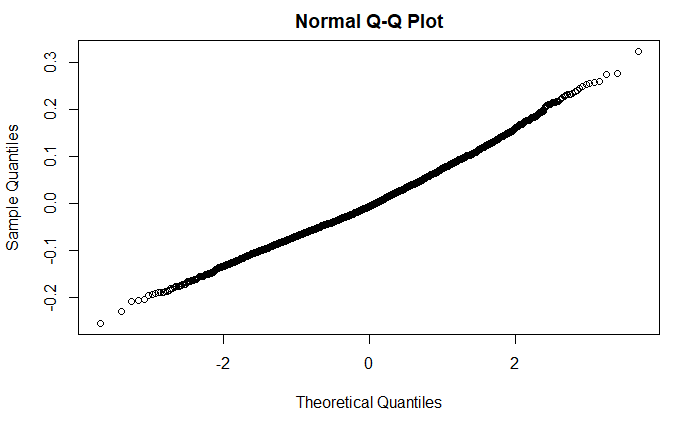

Nice. Out of interest: Do the model predictions change when the data is not normalized?

For comparison the values for the model with normalized data:

Random effects: Groups Name Variance Std.Dev. subject (Intercept) 0.003225 0.05679 Residual 0.005361 0.07322 Number of obs: 4397, groups: subject, 4

Fixed effects: Estimate Std. Error t value (Intercept) 0.554313 0.028443 19.489 pi_pos01 -0.028741 0.001767 -16.269 pi_pos02 -0.048941 0.007733 -6.329 pi_pos03 0.051166 0.006391 8.006

Correlation of Fixed Effects: (Intr) p_ps01 p_ps02 pi_pos01 -0.008  
pi_pos02 -0.009 -0.412  
pi_pos03 -0.013 0.031 -0.752

```r
rtm6_nn <- lmer('rea_time ~ 1 + pi_pos01 + pi_pos02 + pi_pos03 + (1|subject)', data = df, REML = FALSE)

summary(rtm6_nn)
```

```
Linear mixed model fit by maximum likelihood  ['lmerMod']
Formula: rea_time ~ 1 + pi_pos01 + pi_pos02 + pi_pos03 + (1 | subject)
   Data: df

     AIC      BIC   logLik deviance df.resid
-10473.9 -10435.5   5242.9 -10485.9     4391

Scaled residuals:
    Min      1Q  Median      3Q     Max
-3.4867 -0.6857 -0.0876  0.6304  4.4396

Random effects:
 Groups   Name        Variance Std.Dev.
 subject  (Intercept) 0.003225 0.05679
 Residual             0.005361 0.07322
Number of obs: 4397, groups:  subject, 4

Fixed effects:
             Estimate Std. Error t value
(Intercept)  0.598609   0.028646  20.897
pi_pos01    -0.093609   0.005754 -16.269
pi_pos02    -0.048941   0.007733  -6.329
pi_pos03     0.051166   0.006391   8.006

Correlation of Fixed Effects:
         (Intr) p_ps01 p_ps02
pi_pos01 -0.054
pi_pos02 -0.018 -0.412
pi_pos03 -0.026  0.031 -0.752
```

## PART 2 fitting RESPONSES

For the response data we need a model that supports binary outcome. In the R framework, that’s glmer.

Again, we start with fitting a full model that we will reduce iteratively.

```r
# this full model will again run for a long time, so we want to save it.

filename_maxresp <- '../2-3_Fitted/resp_max_lmer.R'

if (file.exists(filename_maxresp)){

  #respm indicates a RESPonses Model
  respm0 <- readRDS(filename_maxresp)

}else {

# First, we fit the maximum model for reaction time
respm0 <- glmer('goResp ~ 1 + pi_pos01 + pi_pos02 + pi_pos03 + pi_pos04 + pi_pos05 + pi_pos06 + posSet_1 + posSet_2 + posSet_3 + posSet_4 + posSet_5 + posSet_6 + pi_pos01:posSet_1 + pi_pos02:posSet_2 + pi_pos03:posSet_3 + pi_pos04:posSet_4 + pi_pos05:posSet_5 + pi_pos06:posSet_6 + (1 + pi_pos01 + pi_pos02 + pi_pos03 + pi_pos04 + pi_pos05 + pi_pos06 + posSet_1 + posSet_2 + posSet_3 + posSet_4 + posSet_5 + posSet_6|subject)', binomial, data = df_norm)


# and we save the model
saveRDS(respm0 , file = filename_maxresp)

}
```

```
maxfun < 10 * length(par)^2 is not recommended.convergence code 1 from bobyqa: bobyqa -- maximum number of function evaluations exceededfailure to converge in 10000 evaluationsconvergence code 4 from Nelder_Mead: failure to converge in 10000 evaluationsboundary (singular) fit: see ?isSingular
```

```r
summary(respm0)
```

```
Generalized linear mixed model fit by maximum likelihood (Laplace Approximation) [
glmerMod]
 Family: binomial  ( logit )
Formula: goResp ~ 1 + pi_pos01 + pi_pos02 + pi_pos03 + pi_pos04 + pi_pos05 +
    pi_pos06 + posSet_1 + posSet_2 + posSet_3 + posSet_4 + posSet_5 +
    posSet_6 + pi_pos01:posSet_1 + pi_pos02:posSet_2 + pi_pos03:posSet_3 +
    pi_pos04:posSet_4 + pi_pos05:posSet_5 + pi_pos06:posSet_6 +
    (1 + pi_pos01 + pi_pos02 + pi_pos03 + pi_pos04 + pi_pos05 +
        pi_pos06 + posSet_1 + posSet_2 + posSet_3 + posSet_4 +
        posSet_5 + posSet_6 | subject)
   Data: df_norm

     AIC      BIC   logLik deviance df.resid
  6193.3   6972.2  -2986.6   5973.3     8679

Scaled residuals:
    Min      1Q  Median      3Q     Max
-8.2813 -0.3299  0.0947  0.2944 11.7923

Random effects:
 Groups  Name        Variance Std.Dev. Corr
 subject (Intercept) 0.406339 0.63745
         pi_pos01    0.134741 0.36707   0.10
         pi_pos02    0.436054 0.66034  -0.99  0.04
         pi_pos03    0.865094 0.93010  -0.04 -0.84 -0.09
         pi_pos04    0.055907 0.23645   0.67 -0.20 -0.70 -0.17
         pi_pos05    0.359987 0.59999   0.06 -0.46 -0.13 -0.08  0.78
         pi_pos06    0.422264 0.64982  -0.46  0.08  0.48  0.38 -0.95 -0.86
         posSet_1    0.009723 0.09861   0.65  0.39 -0.60  0.08 -0.13 -0.72  0.34
         posSet_2    0.010420 0.10208  -0.91  0.27  0.96 -0.18 -0.83 -0.38  0.62
         posSet_3    0.028984 0.17025  -0.59 -0.86  0.46  0.64 -0.09  0.44  0.06
         posSet_4    0.006831 0.08265  -0.72 -0.19  0.69 -0.24  0.03  0.62 -0.29
         posSet_5    0.005821 0.07629   0.79  0.38 -0.74 -0.57  0.82  0.38 -0.79
         posSet_6    0.004905 0.07003  -0.04 -0.27  0.00 -0.29  0.72  0.97 -0.86






```

[output cut: 18 more lines]

```
pi_pos06           1.24847    0.47057   2.653  0.00798 **
posSet_1          -0.02789    0.07190  -0.388  0.69810
posSet_2          -0.04880    0.07355  -0.664  0.50699
posSet_3           0.06179    0.09916   0.623  0.53318
posSet_4           0.08500    0.06467   1.315  0.18868
posSet_5           0.05189    0.06262   0.829  0.40729
posSet_6          -0.05629    0.06083  -0.925  0.35478
pi_pos01:posSet_1 -0.05309    0.04847  -1.095  0.27339
pi_pos02:posSet_2  0.01243    0.14670   0.085  0.93249
pi_pos03:posSet_3 -0.20457    0.12477  -1.640  0.10110
pi_pos04:posSet_4 -0.08051    0.11208  -0.718  0.47255
pi_pos05:posSet_5  0.08708    0.10754   0.810  0.41807
pi_pos06:posSet_6 -0.09875    0.10062  -0.981  0.32637
---
Signif. codes:  0 ‘***’ 0.001 ‘**’ 0.01 ‘*’ 0.05 ‘.’ 0.1 ‘ ’ 1
```

```
Correlation matrix not shown by default, as p = 19 > 12.
Use print(x, correlation=TRUE)  or
    vcov(x)        if you need it
```

```
optimizer (Nelder_Mead) convergence code: 4 (failure to converge in 10000 evaluations)
boundary (singular) fit: see ?isSingular
failure to converge in 10000 evaluations
```

We procede in the same way as for the reaction times above. First, we reduce the random effects structure according to the results from a PCA.

```r
# probe the fitted model with rePCA

respPCA <- rePCA(respm0)
class(respPCA)
```

```
[1] "prcomplist"
```

```r
length(respPCA)
```

```
[1] 1
```

```r
names(respPCA)
```

```
[1] "subject"
```

```r
class(respPCA$subject)
```

```
[1] "prcomp"
```

```r
respPCA$subject
```

```
Standard deviations (1, .., p=13):
 [1] 1.091905e+00 9.785815e-01 7.727224e-01 8.878127e-03 3.233099e-03 1.113050e-03
 [7] 7.535675e-04 3.940711e-04 3.281897e-04 2.406633e-04 1.567390e-04 5.336050e-05
[13] 1.014158e-06

Rotation (n x k) = (13 x 13):
              [,1]         [,2]        [,3]         [,4]        [,5]        [,6]
 [1,] -0.394900371 -0.362962368 -0.39730116 -0.093655224  0.11035358 -0.01762682
 [2,] -0.112243381  0.274403923 -0.28235468 -0.326889276 -0.43507402 -0.17943425
 [3,]  0.380778355  0.451432765  0.33754253  0.005475606 -0.22906903 -0.03105028
 [4,]  0.529882266 -0.737233468  0.12847470 -0.134557775 -0.31444047 -0.09774716
 [5,] -0.185069726 -0.101625462  0.09265074  0.829831646 -0.30052729  0.18512722
 [6,] -0.284778162 -0.119188583  0.64665325 -0.325883846  0.26208840  0.31357222
 [7,]  0.523320634  0.099861321 -0.37994093  0.093957225  0.51620171  0.30211468
 [8,] -0.004863847 -0.027825881 -0.12244750 -0.088630440 -0.18634534  0.39036667
```

[output cut: 33 more lines]

```r
summary(respPCA$subject)
```

```
Importance of components:
                        [,1]   [,2]   [,3]     [,4]     [,5]     [,6]      [,7]
Standard deviation     1.092 0.9786 0.7727 0.008878 0.003233 0.001113 0.0007536
Proportion of Variance 0.434 0.3486 0.2174 0.000030 0.000000 0.000000 0.0000000
Cumulative Proportion  0.434 0.7826 1.0000 1.000000 1.000000 1.000000 1.0000000
                            [,8]      [,9]     [,10]     [,11]     [,12]     [,13]
Standard deviation     0.0003941 0.0003282 0.0002407 0.0001567 5.336e-05 1.014e-06
Proportion of Variance 0.0000000 0.0000000 0.0000000 0.0000000 0.000e+00 0.000e+00
Cumulative Proportion  1.0000000 1.0000000 1.0000000 1.0000000 1.000e+00 1.000e+00
```

The results suggest that we can shorten the random effects structure. Since in the random effects, the least variance is explained by position terms, we take them out.

```r
respm1 <- glmer('goResp ~ 1 + pi_pos01 + pi_pos02 + pi_pos03 + pi_pos04 + pi_pos05 + pi_pos06 + posSet_1 + posSet_2 + posSet_3 + posSet_4 + posSet_5 + posSet_6 + pi_pos01:posSet_1 + pi_pos02:posSet_2 + pi_pos03:posSet_3 + pi_pos04:posSet_4 + pi_pos05:posSet_5 + pi_pos06:posSet_6 + (1 + pi_pos01 + pi_pos02 + pi_pos03 + pi_pos05 + pi_pos06|subject)', binomial, data = df_norm)
```

```
Model failed to converge with max|grad| = 0.00380957 (tol = 0.002, component 1)
```

```r
summary(respm1)
```

```
Generalized linear mixed model fit by maximum likelihood (Laplace Approximation) [
glmerMod]
 Family: binomial  ( logit )
Formula: goResp ~ 1 + pi_pos01 + pi_pos02 + pi_pos03 + pi_pos04 + pi_pos05 +
    pi_pos06 + posSet_1 + posSet_2 + posSet_3 + posSet_4 + posSet_5 +
    posSet_6 + pi_pos01:posSet_1 + pi_pos02:posSet_2 + pi_pos03:posSet_3 +
    pi_pos04:posSet_4 + pi_pos05:posSet_5 + pi_pos06:posSet_6 +
    (1 + pi_pos01 + pi_pos02 + pi_pos03 + pi_pos05 + pi_pos06 |          subject)
   Data: df_norm

     AIC      BIC   logLik deviance df.resid
  6090.2   6373.5  -3005.1   6010.2     8749

Scaled residuals:
    Min      1Q  Median      3Q     Max
-6.7024 -0.3331  0.1239  0.2936 10.9518

Random effects:
 Groups  Name        Variance Std.Dev. Corr
 subject (Intercept) 0.3918   0.6259
         pi_pos01    0.1343   0.3665    0.06
         pi_pos02    0.4232   0.6506   -0.99  0.01
         pi_pos03    0.8206   0.9059    0.01 -0.85 -0.15
         pi_pos05    0.4167   0.6455    0.36 -0.40 -0.26 -0.07
         pi_pos06    0.3636   0.6030   -0.59  0.07  0.47  0.32 -0.92
Number of obs: 8789, groups:  subject, 4

Fixed effects:
                  Estimate Std. Error z value Pr(>|z|)
(Intercept)       -0.12003    0.31515  -0.381  0.70330
pi_pos01           0.47098    0.19217   2.451  0.01425 *
pi_pos02           3.20120    0.39125   8.182 2.79e-16 ***
pi_pos03           1.57955    0.51578   3.062  0.00220 **
pi_pos04          -0.04625    0.31183  -0.148  0.88210
pi_pos05          -0.56074    0.53438  -1.049  0.29402
pi_pos06           1.27708    0.45368   2.815  0.00488 **
posSet_1          -0.01284    0.05034  -0.255  0.79862
posSet_2          -0.07062    0.05148  -1.372  0.17012
posSet_3           0.06127    0.04916   1.246  0.21266
posSet_4           0.07228    0.04844   1.492  0.13568
posSet_5           0.06061    0.04829   1.255  0.20936
posSet_6          -0.05515    0.04867  -1.133  0.25712
pi_pos01:posSet_1 -0.06413    0.04769  -1.345  0.17871
pi_pos02:posSet_2  0.11309    0.13905   0.813  0.41606
pi_pos03:posSet_3 -0.14652    0.11898  -1.231  0.21814
pi_pos04:posSet_4 -0.04799    0.10766  -0.446  0.65580
pi_pos05:posSet_5  0.05358    0.10221   0.524  0.60010
pi_pos06:posSet_6 -0.09487    0.09608  -0.987  0.32347
---
Signif. codes:  0 ‘***’ 0.001 ‘**’ 0.01 ‘*’ 0.05 ‘.’ 0.1 ‘ ’ 1
```

```
Correlation matrix not shown by default, as p = 19 > 12.
Use print(x, correlation=TRUE)  or
    vcov(x)        if you need it
```

```
optimizer (Nelder_Mead) convergence code: 0 (OK)
Model failed to converge with max|grad| = 0.00380957 (tol = 0.002, component 1)
```

Again, we get a convergence warning. So we check the random effects structure again.

```r
summary(rePCA(respm1))
```

```
$subject
Importance of components:
                         [,1]   [,2]   [,3]      [,4]      [,5]      [,6]
Standard deviation     1.0608 0.9787 0.6833 0.0004405 0.0002913 0.0001369
Proportion of Variance 0.4413 0.3756 0.1831 0.0000000 0.0000000 0.0000000
Cumulative Proportion  0.4413 0.8169 1.0000 1.0000000 1.0000000 1.0000000
```

This suggests that we should take out more parameters from the random effects. Please note, that compared to the random effects structure in the response time data, we now have a first component that explains less than 50% of the variance (it was 80% after the first reduction in the rt model)

The random effects here all account for a rather large proportion of variance. The intercept seems to explain little variance here, but it cannot be removed from the random effects structure. Therefore, I will not remove the intercept, but the 3 other variables with the lowest explained variance.

```r
respm2 <- glmer('goResp ~ 1 + pi_pos01 + pi_pos02 + pi_pos03 + pi_pos04 + pi_pos05 + pi_pos06 + posSet_1 + posSet_2 + posSet_3 + posSet_4 + posSet_5 + posSet_6 + pi_pos01:posSet_1 + pi_pos02:posSet_2 + pi_pos03:posSet_3 + pi_pos04:posSet_4 + pi_pos05:posSet_5 + pi_pos06:posSet_6 + (1 + pi_pos02 + pi_pos03 |subject)', binomial, data = df_norm)
```

```
boundary (singular) fit: see ?isSingular
```

```r
summary(respm2)
```

```
Generalized linear mixed model fit by maximum likelihood (Laplace Approximation) [
glmerMod]
 Family: binomial  ( logit )
Formula: goResp ~ 1 + pi_pos01 + pi_pos02 + pi_pos03 + pi_pos04 + pi_pos05 +
    pi_pos06 + posSet_1 + posSet_2 + posSet_3 + posSet_4 + posSet_5 +
    posSet_6 + pi_pos01:posSet_1 + pi_pos02:posSet_2 + pi_pos03:posSet_3 +
    pi_pos04:posSet_4 + pi_pos05:posSet_5 + pi_pos06:posSet_6 +
    (1 + pi_pos02 + pi_pos03 | subject)
   Data: df_norm

     AIC      BIC   logLik deviance df.resid
    6100     6277    -3025     6050     8764

Scaled residuals:
    Min      1Q  Median      3Q     Max
-6.2326 -0.3370  0.1374  0.3084 11.0892

Random effects:
 Groups  Name        Variance Std.Dev. Corr
 subject (Intercept) 0.3892   0.6239
         pi_pos02    0.7084   0.8416   -0.65
         pi_pos03    1.2570   1.1212   -0.13 -0.67
Number of obs: 8789, groups:  subject, 4

Fixed effects:
                   Estimate Std. Error z value Pr(>|z|)
(Intercept)       -0.116301   0.314066  -0.370 0.711155
pi_pos01           0.463374   0.054677   8.475  < 2e-16 ***
pi_pos02           3.128931   0.472064   6.628  3.4e-11 ***
pi_pos03           1.564438   0.611687   2.558 0.010540 *
pi_pos04          -0.025263   0.310289  -0.081 0.935109
pi_pos05          -0.552085   0.418251  -1.320 0.186840
pi_pos06           1.259327   0.332519   3.787 0.000152 ***
posSet_1          -0.009663   0.050011  -0.193 0.846789
posSet_2          -0.070168   0.051316  -1.367 0.171511
posSet_3           0.061743   0.048947   1.261 0.207155
posSet_4           0.065827   0.048181   1.366 0.171858
posSet_5           0.063872   0.048082   1.328 0.184045
posSet_6          -0.052965   0.048428  -1.094 0.274093
pi_pos01:posSet_1 -0.060929   0.047489  -1.283 0.199488
pi_pos02:posSet_2  0.116891   0.138423   0.844 0.398418
pi_pos03:posSet_3 -0.142791   0.118344  -1.207 0.227598
pi_pos04:posSet_4 -0.053313   0.107031  -0.498 0.618409
pi_pos05:posSet_5  0.043797   0.101836   0.430 0.667140
pi_pos06:posSet_6 -0.083020   0.095658  -0.868 0.385457
---
Signif. codes:  0 ‘***’ 0.001 ‘**’ 0.01 ‘*’ 0.05 ‘.’ 0.1 ‘ ’ 1
```

```
Correlation matrix not shown by default, as p = 19 > 12.
Use print(x, correlation=TRUE)  or
    vcov(x)        if you need it
```

```
optimizer (Nelder_Mead) convergence code: 0 (OK)
boundary (singular) fit: see ?isSingular
```

Still, this does not converge.

```r
summary(rePCA(respm2))
```

```
$subject
Importance of components:
                         [,1]   [,2] [,3]
Standard deviation     1.2979 0.8185    0
Proportion of Variance 0.7155 0.2846    0
Cumulative Proportion  0.7155 1.0000    1
```

We will remove one more parameter from the random effects

```r
respm3 <- glmer('goResp ~ 1 + pi_pos01 + pi_pos02 + pi_pos03 + pi_pos04 + pi_pos05 + pi_pos06 + posSet_1 + posSet_2 + posSet_3 + posSet_4 + posSet_5 + posSet_6 + pi_pos01:posSet_1 + pi_pos02:posSet_2 + pi_pos03:posSet_3 + pi_pos04:posSet_4 + pi_pos05:posSet_5 + pi_pos06:posSet_6 + (1 + pi_pos03 |subject)', binomial, data = df_norm)

summary(respm3)
```

```
Generalized linear mixed model fit by maximum likelihood (Laplace Approximation) [
glmerMod]
 Family: binomial  ( logit )
Formula: goResp ~ 1 + pi_pos01 + pi_pos02 + pi_pos03 + pi_pos04 + pi_pos05 +
    pi_pos06 + posSet_1 + posSet_2 + posSet_3 + posSet_4 + posSet_5 +
    posSet_6 + pi_pos01:posSet_1 + pi_pos02:posSet_2 + pi_pos03:posSet_3 +
    pi_pos04:posSet_4 + pi_pos05:posSet_5 + pi_pos06:posSet_6 +
    (1 + pi_pos03 | subject)
   Data: df_norm

     AIC      BIC   logLik deviance df.resid
  6111.8   6267.6  -3033.9   6067.8     8767

Scaled residuals:
    Min      1Q  Median      3Q     Max
-6.8980 -0.3300  0.1233  0.3182 11.0110

Random effects:
 Groups  Name        Variance Std.Dev. Corr
 subject (Intercept) 0.3881   0.6230
         pi_pos03    0.7198   0.8484   -0.59
Number of obs: 8789, groups:  subject, 4

Fixed effects:
                  Estimate Std. Error z value Pr(>|z|)
(Intercept)       -0.09872    0.31348  -0.315 0.752828
pi_pos01           0.46194    0.05467   8.450  < 2e-16 ***
pi_pos02           3.00450    0.20855  14.407  < 2e-16 ***
pi_pos03           1.65838    0.48813   3.397 0.000680 ***
pi_pos04          -0.03051    0.31016  -0.098 0.921647
pi_pos05          -0.54444    0.41794  -1.303 0.192692
pi_pos06           1.24662    0.33222   3.752 0.000175 ***
posSet_1          -0.01229    0.04989  -0.246 0.805446
posSet_2          -0.07762    0.05115  -1.517 0.129156
posSet_3           0.07197    0.04867   1.479 0.139172
posSet_4           0.06495    0.04806   1.351 0.176563
posSet_5           0.06327    0.04800   1.318 0.187463
posSet_6          -0.05337    0.04831  -1.105 0.269268
pi_pos01:posSet_1 -0.06633    0.04747  -1.397 0.162293
pi_pos02:posSet_2  0.11035    0.13808   0.799 0.424207
pi_pos03:posSet_3 -0.13256    0.11766  -1.127 0.259873
pi_pos04:posSet_4 -0.04279    0.10662  -0.401 0.688192
pi_pos05:posSet_5  0.04648    0.10160   0.457 0.647363
pi_pos06:posSet_6 -0.08373    0.09539  -0.878 0.380056
---
Signif. codes:  0 ‘***’ 0.001 ‘**’ 0.01 ‘*’ 0.05 ‘.’ 0.1 ‘ ’ 1
```

```
Correlation matrix not shown by default, as p = 19 > 12.
Use print(x, correlation=TRUE)  or
    vcov(x)        if you need it
```

This model converges. However, we want to know if removing the last random intercept as well improves the model.

```r
respm4 <- glmer('goResp ~ 1 + pi_pos01 + pi_pos02 + pi_pos03 + pi_pos04 + pi_pos05 + pi_pos06 + posSet_1 + posSet_2 + posSet_3 + posSet_4 + posSet_5 + posSet_6 + pi_pos01:posSet_1 + pi_pos02:posSet_2 + pi_pos03:posSet_3 + pi_pos04:posSet_4 + pi_pos05:posSet_5 + pi_pos06:posSet_6 + (1 |subject)', binomial, data = df_norm)

summary(respm4)
```

```
Generalized linear mixed model fit by maximum likelihood (Laplace Approximation) [
glmerMod]
 Family: binomial  ( logit )
Formula: goResp ~ 1 + pi_pos01 + pi_pos02 + pi_pos03 + pi_pos04 + pi_pos05 +
    pi_pos06 + posSet_1 + posSet_2 + posSet_3 + posSet_4 + posSet_5 +
    posSet_6 + pi_pos01:posSet_1 + pi_pos02:posSet_2 + pi_pos03:posSet_3 +
    pi_pos04:posSet_4 + pi_pos05:posSet_5 + pi_pos06:posSet_6 +      (1 | subject)
   Data: df_norm

     AIC      BIC   logLik deviance df.resid
  6159.6   6301.2  -3059.8   6119.6     8769

Scaled residuals:
    Min      1Q  Median      3Q     Max
-7.2401 -0.3293  0.1169  0.3203  8.2259

Random effects:
 Groups  Name        Variance Std.Dev.
 subject (Intercept) 0.3351   0.5789
Number of obs: 8789, groups:  subject, 4

Fixed effects:
                   Estimate Std. Error z value Pr(>|z|)
(Intercept)       -0.052443   0.291366  -0.180 0.857161
pi_pos01           0.464086   0.054565   8.505  < 2e-16 ***
pi_pos02           2.938769   0.206875  14.206  < 2e-16 ***
pi_pos03           1.649677   0.238896   6.905 5.01e-12 ***
pi_pos04          -0.033307   0.308749  -0.108 0.914094
pi_pos05          -0.531536   0.414889  -1.281 0.200140
pi_pos06           1.234404   0.328925   3.753 0.000175 ***
posSet_1          -0.008471   0.049599  -0.171 0.864385
posSet_2          -0.080026   0.051027  -1.568 0.116808
posSet_3           0.069084   0.048428   1.427 0.153717
posSet_4           0.062634   0.047826   1.310 0.190325
posSet_5           0.062615   0.047725   1.312 0.189526
posSet_6          -0.053651   0.048128  -1.115 0.264954
pi_pos01:posSet_1 -0.066976   0.047293  -1.416 0.156723
pi_pos02:posSet_2  0.129157   0.138049   0.936 0.349487
pi_pos03:posSet_3 -0.154951   0.117230  -1.322 0.186245
pi_pos04:posSet_4 -0.035672   0.106187  -0.336 0.736921
pi_pos05:posSet_5  0.052726   0.100957   0.522 0.601486
pi_pos06:posSet_6 -0.087736   0.095042  -0.923 0.355939
---
Signif. codes:  0 ‘***’ 0.001 ‘**’ 0.01 ‘*’ 0.05 ‘.’ 0.1 ‘ ’ 1
```

```
Correlation matrix not shown by default, as p = 19 > 12.
Use print(x, correlation=TRUE)  or
    vcov(x)        if you need it
```

This suggest that it improves the model to include the additional random effect We will continue reducing the fixed effects from model respm3

In this output, we actually get significance values for the test statistics. Those values are hard to interpret for mixed effect models, but they can serve as a proxy to speed up our model reduction.

In the next step, we will exclude all terms that were non-significant at alpha = 0.05

```r
respm5 <- glmer('goResp ~ 1 + pi_pos01 + pi_pos02 + pi_pos03 + pi_pos06+ (1 + pi_pos03 | subject)', binomial, data = df_norm)

summary(respm5)
```

```
Generalized linear mixed model fit by maximum likelihood (Laplace Approximation) [
glmerMod]
 Family: binomial  ( logit )
Formula: goResp ~ 1 + pi_pos01 + pi_pos02 + pi_pos03 + pi_pos06 + (1 +
    pi_pos03 | subject)
   Data: df_norm

     AIC      BIC   logLik deviance df.resid
  6103.3   6160.0  -3043.7   6087.3     8781

Scaled residuals:
    Min      1Q  Median      3Q     Max
-6.8090 -0.3299  0.1399  0.3178  9.2470

Random effects:
 Groups  Name        Variance Std.Dev. Corr
 subject (Intercept) 0.3863   0.6215
         pi_pos03    0.7210   0.8491   -0.58
Number of obs: 8789, groups:  subject, 4

Fixed effects:
            Estimate Std. Error z value Pr(>|z|)
(Intercept) -0.09588    0.31276  -0.307  0.75918
pi_pos01     0.45355    0.05445   8.330  < 2e-16 ***
pi_pos02     3.01931    0.20780  14.530  < 2e-16 ***
pi_pos03     1.54580    0.47097   3.282  0.00103 **
pi_pos06     0.77203    0.13055   5.914 3.34e-09 ***
---
Signif. codes:  0 ‘***’ 0.001 ‘**’ 0.01 ‘*’ 0.05 ‘.’ 0.1 ‘ ’ 1

Correlation of Fixed Effects:
         (Intr) p_ps01 p_ps02 p_ps03
pi_pos01 -0.005
pi_pos02  0.002 -0.485
pi_pos03 -0.523  0.015 -0.217
pi_pos06 -0.001  0.033 -0.001 -0.292
```

Next, we compare this model to the earlier models using AIC.

```r
list(summary(respm0)$AIC[1], summary(respm1)$AIC[1], summary(respm2)$AIC[1], summary(respm3)$AIC[1], summary(respm4)$AIC[1], summary(respm5)$AIC[1])
```

```
[[1]]
     AIC
6193.284

[[2]]
     AIC
6090.245

[[3]]
     AIC
6099.959

[[4]]
     AIC
6111.826

[[5]]
     AIC
6159.597

[[6]]
    AIC
6103.33
```

Again, some of the models that did not converge had lower AICs than the last model. But the last model (respm5) has the lowest AIC among the models that did converge. So that model wins the response model race.

We save that model

```r
# check if the model was already fitted
filename_bestfitresp <- '../2-3_Fitted/resp_bestfit_lmer.R'

if (file.exists(filename_bestfitresp)){

  #rtm indicates a ReactionTime Model
  print('the file already exists. it was not overwritten.')

}else {

# we save the model
saveRDS(respm5 , file = filename_bestfitresp)

}

# and we print the summary a last time
summary(respm5)
```

```
Generalized linear mixed model fit by maximum likelihood (Laplace Approximation) [
glmerMod]
 Family: binomial  ( logit )
Formula: goResp ~ 1 + pi_pos01 + pi_pos02 + pi_pos03 + pi_pos06 + (1 +
    pi_pos03 | subject)
   Data: df_norm

     AIC      BIC   logLik deviance df.resid
  6103.3   6160.0  -3043.7   6087.3     8781

Scaled residuals:
    Min      1Q  Median      3Q     Max
-6.8090 -0.3299  0.1399  0.3178  9.2470

Random effects:
 Groups  Name        Variance Std.Dev. Corr
 subject (Intercept) 0.3863   0.6215
         pi_pos03    0.7210   0.8491   -0.58
Number of obs: 8789, groups:  subject, 4

Fixed effects:
            Estimate Std. Error z value Pr(>|z|)
(Intercept) -0.09588    0.31276  -0.307  0.75918
pi_pos01     0.45355    0.05445   8.330  < 2e-16 ***
pi_pos02     3.01931    0.20780  14.530  < 2e-16 ***
pi_pos03     1.54580    0.47097   3.282  0.00103 **
pi_pos06     0.77203    0.13055   5.914 3.34e-09 ***
---
Signif. codes:  0 ‘***’ 0.001 ‘**’ 0.01 ‘*’ 0.05 ‘.’ 0.1 ‘ ’ 1

Correlation of Fixed Effects:
         (Intr) p_ps01 p_ps02 p_ps03
pi_pos01 -0.005
pi_pos02  0.002 -0.485
pi_pos03 -0.523  0.015 -0.217
pi_pos06 -0.001  0.033 -0.001 -0.292
```

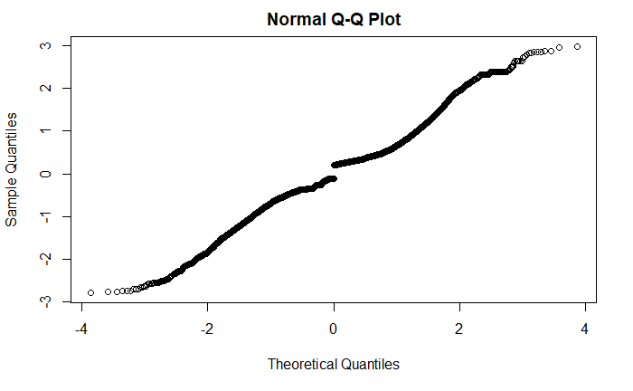

Finally, we check again if we would have gotten a different result if the data had been normalized.

```r
summary(respm5_nn)
```

[output not shown]

```
Generalized linear mixed model fit by maximum likelihood (Laplace Approximation) [
glmerMod]
 Family: binomial  ( logit )
Formula: goResp ~ 1 + pi_pos01 + pi_pos02 + pi_pos03 + pi_pos06 + (1 +
    pi_pos03 | subject)
   Data: df

     AIC      BIC   logLik deviance df.resid
  6103.3   6160.0  -3043.7   6087.3     8781

Scaled residuals:
    Min      1Q  Median      3Q     Max
-6.8090 -0.3299  0.1399  0.3178  9.2470

Random effects:
 Groups  Name        Variance Std.Dev. Corr
 subject (Intercept) 0.8717   0.9336
         pi_pos03    0.7210   0.8491   -0.84
Number of obs: 8789, groups:  subject, 4

Fixed effects:
            Estimate Std. Error z value Pr(>|z|)
(Intercept)  -3.4683     0.4749  -7.304 2.80e-13 ***
pi_pos01      1.4772     0.1773   8.333  < 2e-16 ***
pi_pos02      3.0193     0.2077  14.536  < 2e-16 ***
pi_pos03      1.5458     0.4709   3.282  0.00103 **
pi_pos06      0.7720     0.1305   5.915 3.32e-09 ***
---
Signif. codes:  0 ‘***’ 0.001 ‘**’ 0.01 ‘*’ 0.05 ‘.’ 0.1 ‘ ’ 1

Correlation of Fixed Effects:
         (Intr) p_ps01 p_ps02 p_ps03
pi_pos01 -0.092
pi_pos02 -0.020 -0.485
pi_pos03 -0.755  0.015 -0.217
pi_pos06  0.001  0.033 -0.001 -0.292
```

The estimates change - but that’s ok and simply indicates that the values have changed during normalization (which is in the end the reason why we normalize data).

## SUMMARY

For response time and response category each, we fitted the maximal model, including: main effects for probability and position at every timepoint interaction between probability and position at common time points (i.e. probability1:position1 etc)

random effects for all main effects.

We iteratively reduced the model, first eliminating random effects that explained little to no variance until the model was well specified. (the variance-covariance matrix was not singular and the model converged during training)

Next, we reduced the fixed effects, by removing those fixed effects that explained little to no variance.

Finally, all models were compared with AIC. We only considered models that were well specified into the selection of the winning model. The model with the lowest AIC was chosen as the winning model.

In the winning model, we checked if model changed when the independent variables were normalized. Neither of the winning models made different predictions for normalized vs non-normalized data.

For reaction times, the winning model was:

rea_time ~ 1 + pi_pos01 + pi_pos02 + pi_pos03 + (1 | subject)

For responses, the winning model was:

goResp ~ 1 + pi_pos01 + pi_pos02 + pi_pos03 + pi_pos06 + (1 + pi_pos03 | subject)